# Nivel de Impacto del Conflicto Armado Interno en la migración rural (1993–2017)

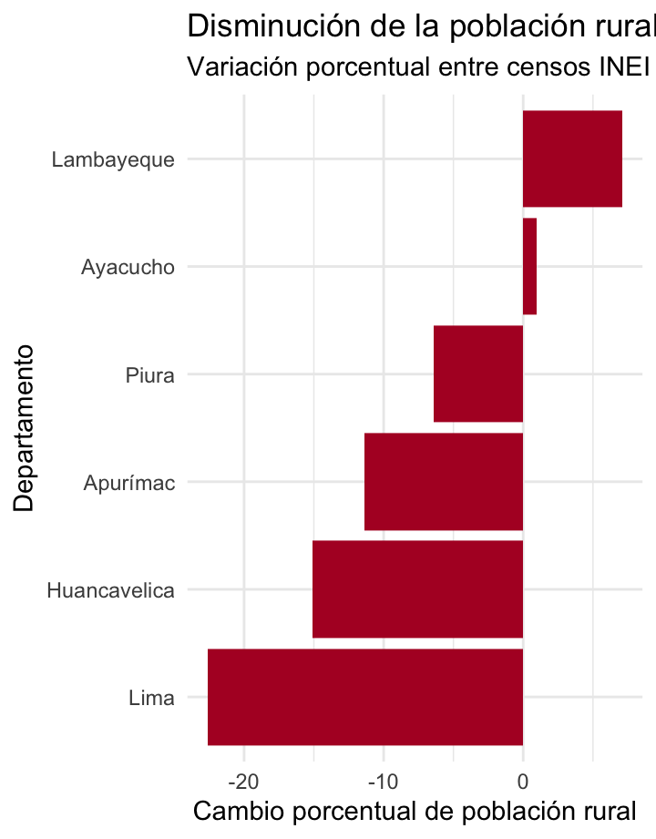

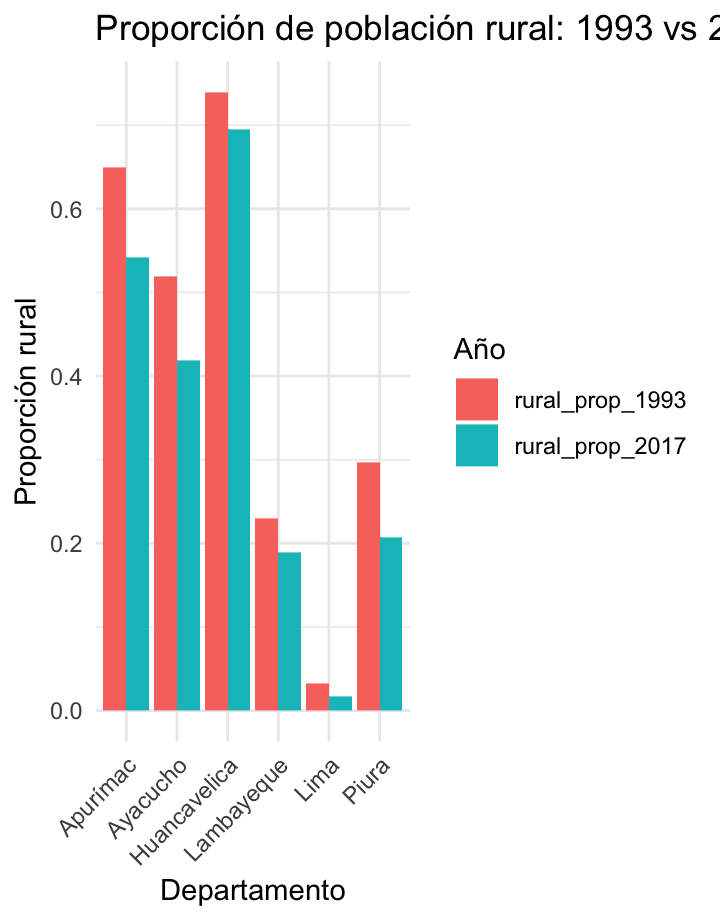

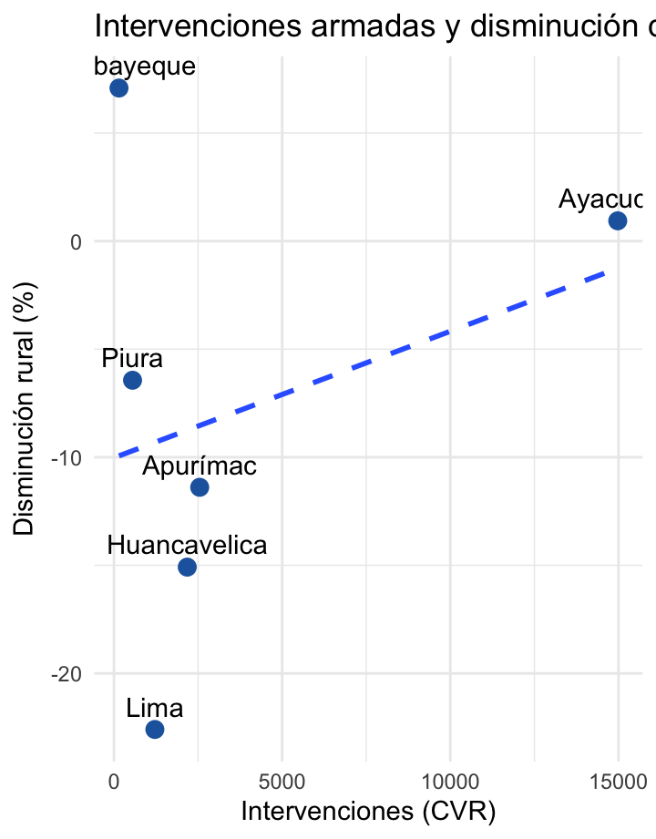

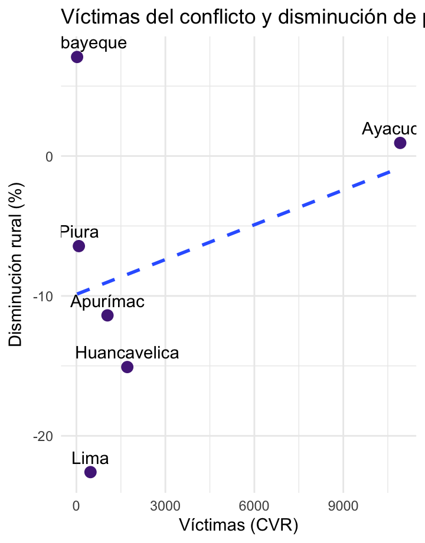

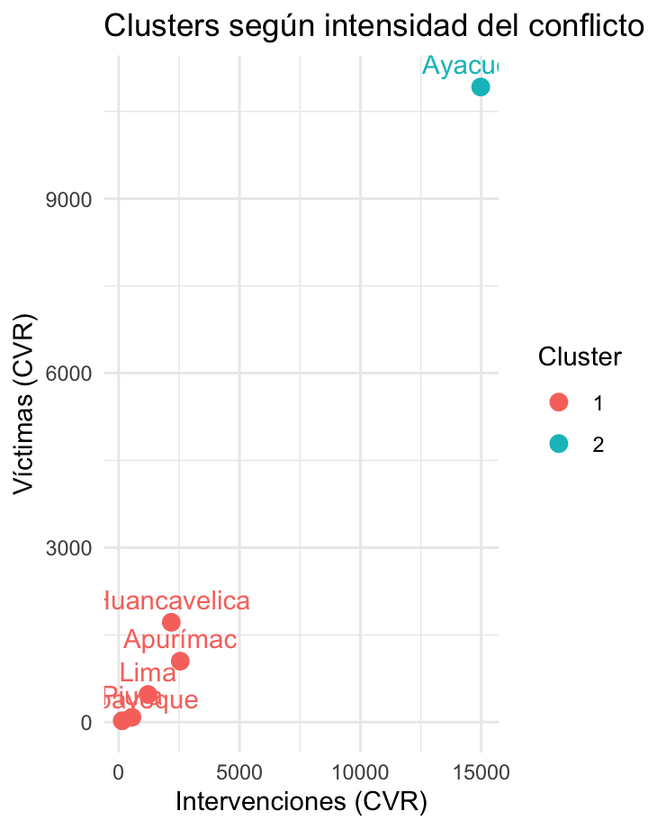

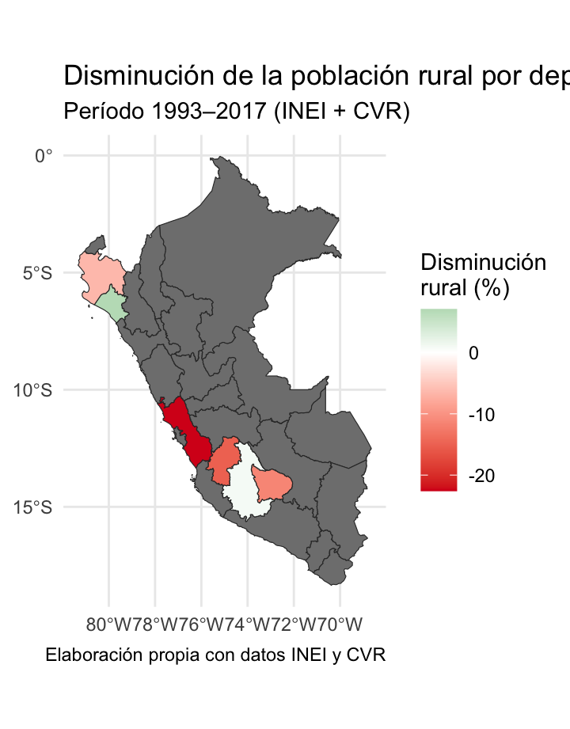

# Introducción y datos

Este dashboard permite visualizar de manera interactiva cómo la intensidad del conflicto armado interno pudo haber influido en la transformación demográfica rural en seis departamentos del Perú.

### **Contexto**

El objetivo de este análisis es evaluar la relación entre:

- la intensidad del conflicto armado interno (intervenciones y víctimas registradas por la CVR), y
- ld disminución de la población rural entre 1993 y 2017, usando datos censales del INEI y datos del conflicto provenientes de la Comisión de la Verdad y Reconciliación (CVR).

El foco está en los departamentos de Ayacucho, Apurímac, Huancavelica, Piura, Lambayeque y Lima, que combinan distintos niveles de violencia política y dinámicas demográficas.

### **Vista general de la base**

|  | departamentos | total_1993 | urbana_1993 | rural_1993 | total_2017 | urbana_2017 | rural_2017 | disminucion_rural | intervenciones_cvr | victimas_CVR | rural_prop_1993 | rural_prop_2017 |
| --- | --- | --- | --- | --- | --- | --- | --- | --- | --- | --- | --- | --- |
| 1 | Apurímac | 381997 | 133949 | 248048 | 405759 | 185964 | 219795 | -11.3901341675805 | 2548 | 1048 | 0.649345413707437 | 0.541688539256061 |
| 2 | Ayacucho | 492507 | 236774 | 255733 | 616176 | 358045 | 258131 | 0.937696738395123 | 14979 | 10919 | 0.519247442168335 | 0.418924138557815 |
| 3 | Huancavelica | 385162 | 100439 | 284723 | 347639 | 105862 | 241777 | -15.0834319672102 | 2178 | 1716 | 0.739229207450372 | 0.695482957895978 |
| 4 | Lambayeque | 920795 | 709608 | 211187 | 1197260 | 971121 | 226139 | 7.07998124884581 | 148 | 23 | 0.229352896138663 | 0.188880443679735 |
| 5 | Lima | 6386308 | 6178820 | 207488 | 9485405 | 9324796 | 160609 | -22.5935957742134 | 1215 | 475 | 0.0324895072395506 | 0.0169322237690431 |
| 6 | Piura | 1388264 | 976798 | 411466 | 1856809 | 1471833 | 384976 | -6.43795599150355 | 551 | 83 | 0.296388871280967 | 0.207332041152321 |

### **Estadísticos generales**

Resumen de la disminución de ruralidad

Resumen de la disminución de la población rural (1993–2017)

| min | q1 | mediana | mean | q3 | max |
| --- | --- | --- | --- | --- | --- |
| -22.5936 | -14.16011 | -8.914045 | -7.914573 | -0.9062164 | 7.079981 |

**Número de departamentos y rango de conflicto**

Resumen de intensidad del conflicto por departamento

| n_deptos | min_int | max_int | min_vic | max_vic |
| --- | --- | --- | --- | --- |
| 6 | 148 | 14979 | 23 | 10919 |

# Página 2: Variable central

La variable central del análisis es la disminución porcentual de población rural. Se observa heterogeneidad marcada entre departamentos.

### **Disminución de población rural por departamento**

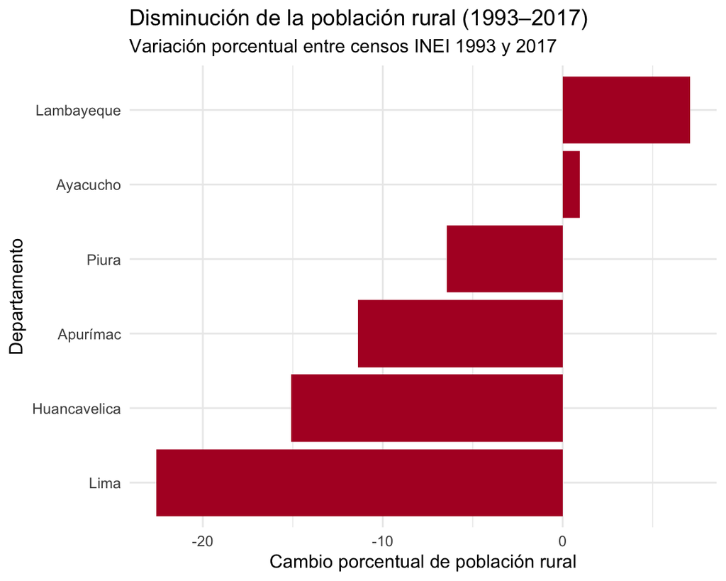

### **Comparación ruralidad 1993 vs 2017**

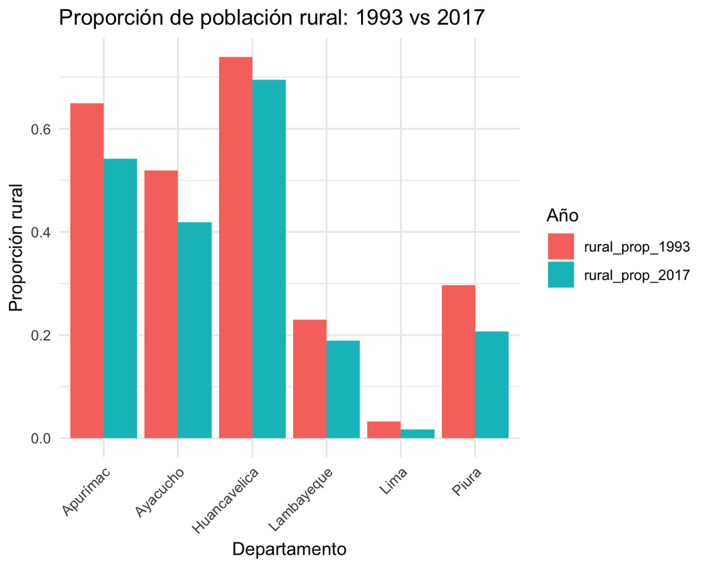

# Página 3: Asociación, correlación y regresión

### **Correlaciones**

Matriz de correlación

Matriz de correlación entre variables clave

|  | disminucion_rural | intervenciones_cvr | victimas_CVR |
| --- | --- | --- | --- |
| disminucion_rural | 1.000 | 0.306 | 0.324 |
| intervenciones_cvr | 0.306 | 1.000 | 0.997 |
| victimas_CVR | 0.324 | 0.997 | 1.000 |

Correlaciones y significancia estadística

| par | correlación | p_value |
| --- | --- | --- |
| Disminución rural ~ Intervenciones CVR | 0.306 | 0.5557 |
| Disminución rural ~ Víctimas CVR | 0.324 | 0.5306 |

### **Modelos de regresión**

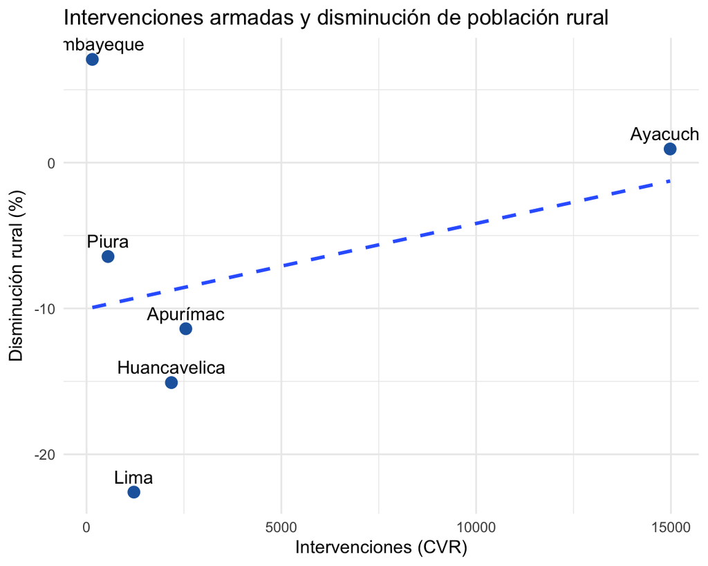

### **Dispersión: víctimas y disminución rural**

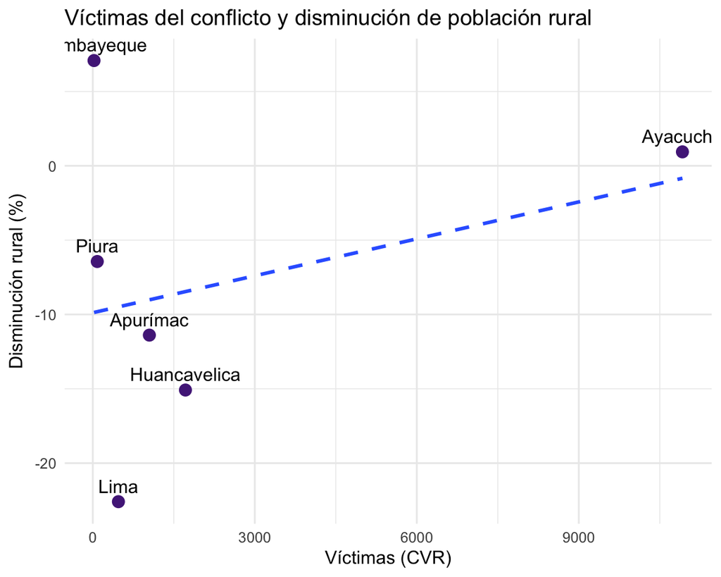

### **Modelo de regresión múltiple**

Modelo de regresión múltiple: disminución rural ~ conflicto

| term | estimate | std.error | statistic | p.value |
| --- | --- | --- | --- | --- |
| (Intercept) | -7.3287 | 8.4705 | -0.865 | 0.451 |
| intervenciones_cvr | -0.0058 | 0.0133 | -0.437 | 0.691 |
| victimas_CVR | 0.0085 | 0.0177 | 0.483 | 0.662 |

Bondad de ajuste del modelo

| r.squared | adj.r.squared | sigma | statistic | p.value | df | AIC | BIC |
| --- | --- | --- | --- | --- | --- | --- | --- |
| 0.1589 | -0.4019 | 12.7997 | 0.2833 | 0.7714 | 2 | 51.4615 | 50.6285 |

# Página 4: Clusterización

### **Tabla de departamentos por cluster**

|  | departamentos | disminucion_rural | intervenciones_cvr | victimas_CVR | cluster |
| --- | --- | --- | --- | --- | --- |
| 1 | Apurímac | -11.3901341675805 | 2548 | 1048 | 1 |
| 2 | Ayacucho | 0.937696738395123 | 14979 | 10919 | 2 |
| 3 | Huancavelica | -15.0834319672102 | 2178 | 1716 | 1 |
| 4 | Lambayeque | 7.07998124884581 | 148 | 23 | 1 |
| 5 | Lima | -22.5935957742134 | 1215 | 475 | 1 |
| 6 | Piura | -6.43795599150355 | 551 | 83 | 1 |

### **Clusters según intensidad del conflicto armado interno**

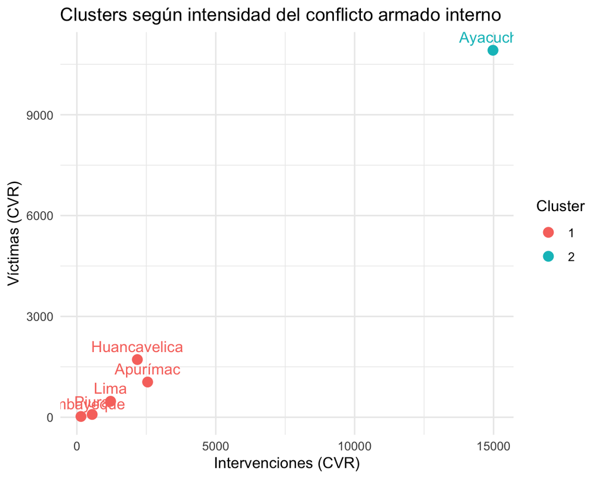

El análisis de clusters identifica dos grupos: uno compuesto por Ayacucho (alta exposición) y otro con los demás departamentos (exposición moderada).

# Página 5: Mapa del Perú

### Mapa de disminución rural por departamento (1993–2017)

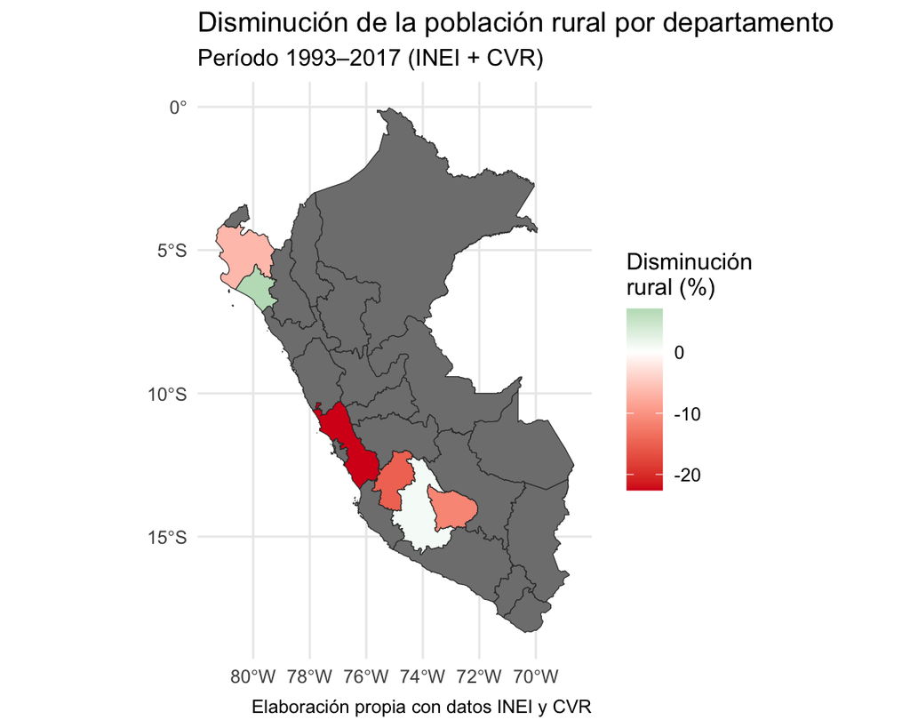